# Lab 04 Personality and green reputation

Shafayet Shariar Hossain

2/10/2022

## Load packages and data

```r
library(tidyverse)
library(gapminder)
library(reshape2)
library(gridExtra)

dictionary <- readr::read_csv(here::here("data", "green_dictionary.csv"))
green_data <- readr::read_csv(here::here("data", "green_data.csv"))
```

## Exercises

### Exercise 1

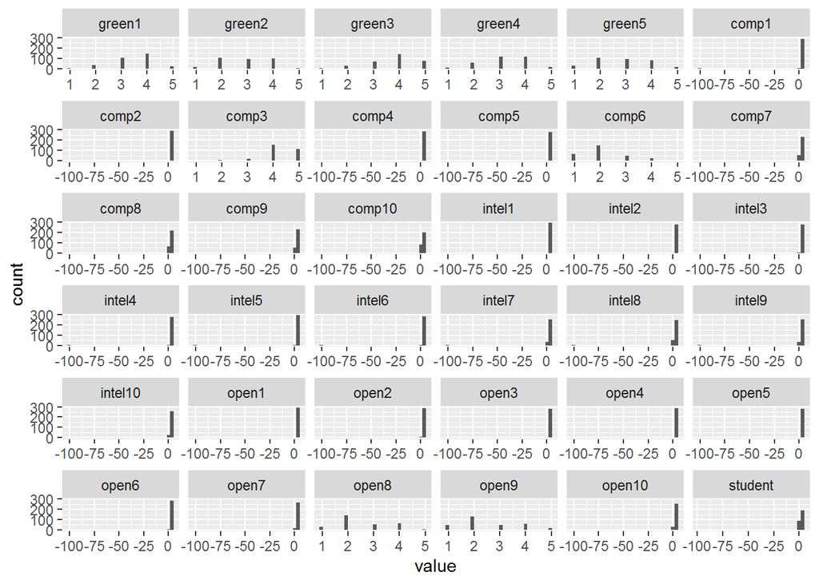

```r
ggplot(melt(green_data))+
  aes(x = value)+
  facet_wrap(~variable, scales = 'free_x')+
  geom_histogram(na.rm = TRUE)
```

```r
green_data|>
  select(-id)|>
  unlist()|>
  unique()
```

```
## [1]   4   3   1  NA   5   2 -99
```

From the plot and unique values of the data frame it can be observed that many of the variables have both NA and -99 as missing values. Therefore, we need to recode -99 as missing value.

```r
# Recoding -99 as the missing value

green_data <- green_data |>
  mutate_at(vars(-id), list(~recode(.,'1'=1,'2'=2,'3'=3,'4'=4,'5'=5, .default = NA_real_)))

green_data|>
  select(-id)|>
  unlist()|>
  unique()
```

```
## [1]  4  3  1 NA  5  2
```

Now it can be observed that the missing values are only coded as NA.

```r
# Reverse coding the columns which have -1 value in the keying column of the dictionary file

new_green_data <- green_data |>
                      mutate_at(dictionary |>
                                filter(Keying == -1) |>
                                select(Item) |>
                                pull(),
                                list(~recode(.,'1'=5,'2'=4,'4'=2,'5'=1)))
```

### Exercise 2

```r
# Total scores of the four scales

new_green_data <- new_green_data |>
  drop_na()

new_green_data <- new_green_data |>
  rowwise() |>
  mutate(
    green_total = sum(c_across(starts_with('green')), na.rm = TRUE),
    comp_total = sum(c_across(starts_with('comp')), na.rm = TRUE),
    intel_total = sum(c_across(starts_with('intel')), na.rm = TRUE),
    open_total = sum(c_across(starts_with('open')), na.rm = TRUE),
    .before = green1,

  )|>
  ungroup()
```

### Exercise 3

```r
# Rescale the variables from 0-100. Formula to calculate POMP= 100*(raw - min)/(max - min)

pomp_function <- function(x){
  round((x-min(x))/(max(x)-min(x))*100,2)
}

new_green_data <- new_green_data |>
  mutate(
    across(
      c(green_total:open_total),
      ~pomp_function(.x),
      .names = '{.col}_pomp'
    ),
    .after = id
  )
```

### Exercise 4

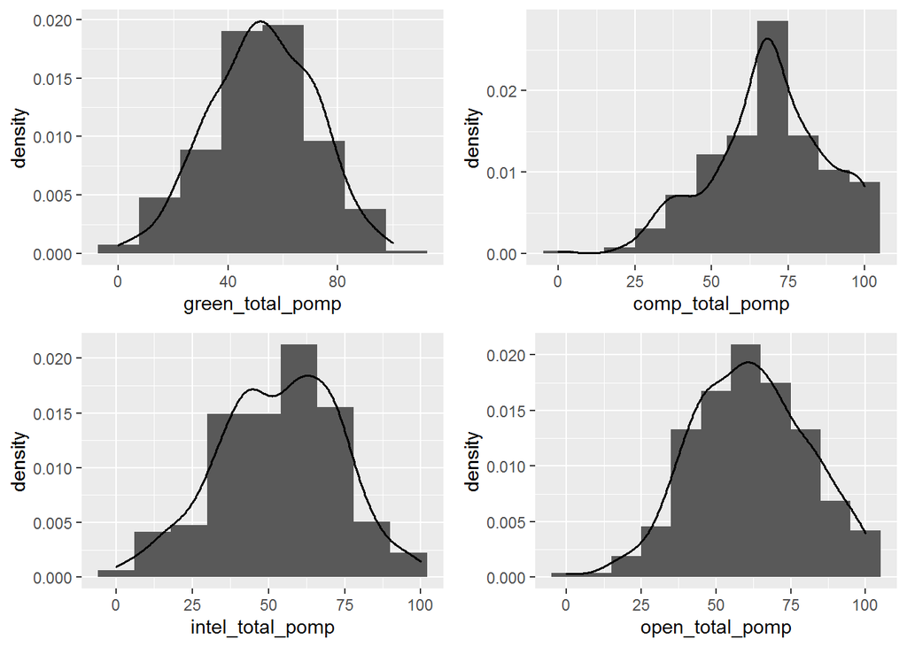

```r
p <- ggplot(new_green_data)+
  aes( x = green_total_pomp)+
  geom_histogram(aes(y = ..density..), position = 'identity', binwidth = 15)+
  geom_density(size = .6, aes(y = ..density..))

q <- ggplot(new_green_data)+
  aes( x = comp_total_pomp)+
  geom_histogram(aes(y = ..density..), position = 'identity', binwidth = 10)+
  geom_density(size = .6, aes(y = ..density..))


r <- ggplot(new_green_data)+
  aes( x = intel_total_pomp)+
  geom_histogram(aes(y = ..density..), position = 'identity', binwidth = 12)+
  geom_density(size = .6, aes(y = ..density..))

s <- ggplot(new_green_data)+
  aes( x = open_total_pomp)+
  geom_histogram(aes(y = ..density..), position = 'identity', binwidth = 10)+
  geom_density(size = .6, aes(y = ..density..))

grid.arrange(p,q,r,s, nrow = 2)
```

### Exercise 5

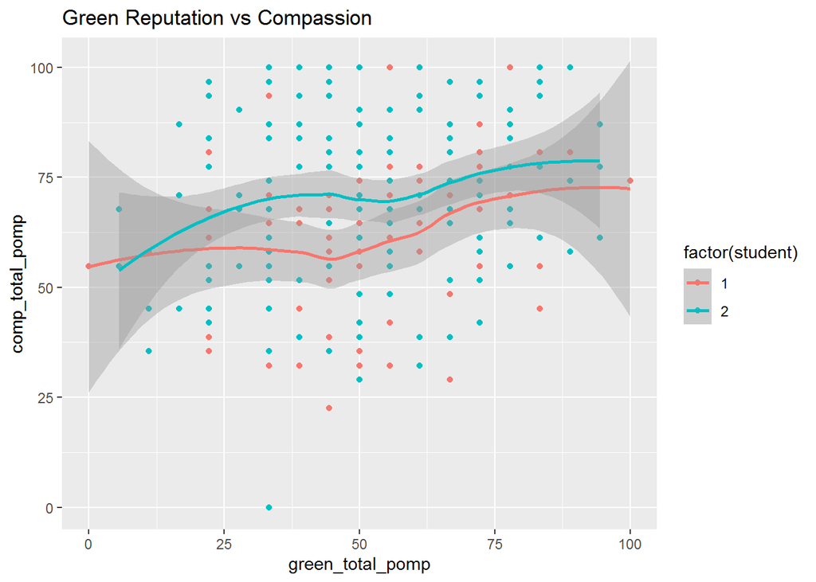

```r
ggplot(new_green_data)+
  aes(x = green_total_pomp, y = comp_total_pomp, color = factor(student))+
  geom_point()+
  geom_smooth()+
  labs(title = 'Green Reputation vs Compassion')
```

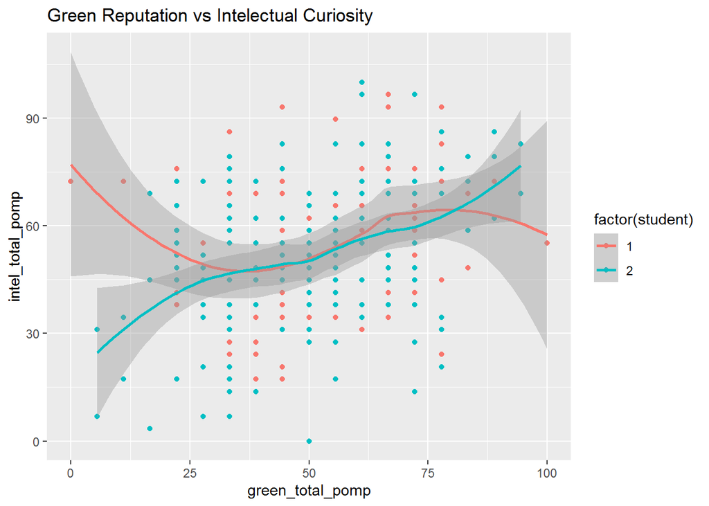

```r
ggplot(new_green_data)+
  aes(x = green_total_pomp, y = intel_total_pomp, color = factor(student))+
  geom_point()+
  geom_smooth()+
  labs(title = 'Green Reputation vs Intelectual Curiosity')
```

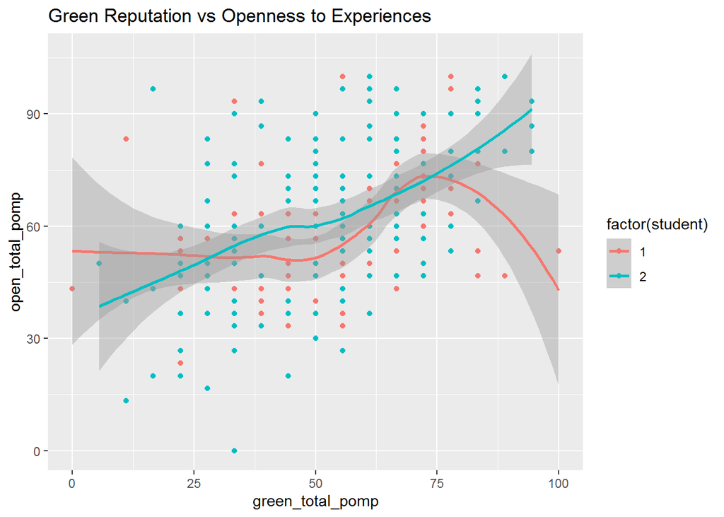

```r
ggplot(new_green_data)+
  aes(x = green_total_pomp, y = open_total_pomp, color = factor(student))+
  geom_point()+
  geom_smooth()+
  labs(title = 'Green Reputation vs Openness to Experiences')
```

From the above 3 scatterplot it can be observed that the relationship between green reputation and the 3 personality traits differ across the student status of the individuals. In green reputation vs compassion plot it can be observed that for both student and non-student individuals the trend line is similar. However, students have higher compassion score than non-students. In green reputation vs intellectual curiosity plot those who are students have a positive curve linear relationship which denotes that as green reputation score increase their intellectual curiosity also increases. For non-students not much definitive can be answered from the trend lines. Similar things can be said from the green reputation vs openness to experience plot. For students as green reputation score increases so does opennes to experiences. For non-students no pattern is apparent.

### Exercise 6

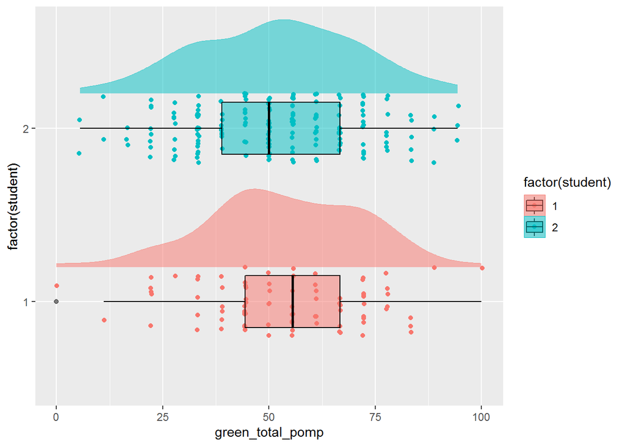

```r
ggplot(new_green_data) +
  aes(x = green_total_pomp, y = factor(student), fill = factor(student), color = factor(student)) +
  geom_jitter(height = 0.2, width = 0.2) +
  geom_boxplot(alpha = 0.5, width = 0.3, color = 'black') +
  ggdist::stat_slab(position = position_nudge(y = 0.2),
                    alpha = 0.5, size = 0.1, height = 0.5)
```

### Exercise 7

```r
new_green_data|>
  group_by(factor(student))|>
  summarise(across(c(green_total,comp_total,intel_total,open_total), list(mean = mean, stddev = sd, median = median, min = min, max = max)))|>
  as.data.frame()
```

```
##   factor(student) green_total_mean green_total_stddev green_total_median
## 1               1         16.67059           3.346598                 17
## 2               2         16.32584           3.428941                 16
##   green_total_min green_total_max comp_total_mean comp_total_stddev
## 1               7              25        38.36471          5.335967
## 2               8              24        41.12360          5.690353
##   comp_total_median comp_total_min comp_total_max intel_total_mean
## 1                40             26             50         36.00000
## 2                41             19             50         35.21348
##   intel_total_stddev intel_total_median intel_total_min intel_total_max
## 1           5.589105                 37              25              48
## 2           5.766594                 36              20              49
##   open_total_mean open_total_stddev open_total_median open_total_min
## 1        35.62353          5.056765                35             25
## 2        36.69663          5.973396                37             18
##   open_total_max
## 1             48
## 2             48
```